# Practical Session 10

## Assessing the impact of interventions using surveillance data

## Expected learning outcomes

By the end of the case study, participants will be able to:

- assess and interpret the effect of an intervention on trends and periodicity in surveillance data

## Description of the dataset

Rotavirus is a very common and potentially serious infection of the large bowel, mainly affecting young babies. Nearly every child will have at least one episode of rotavirus gastroenteritis by five years of age. People of any age can be affected, but the illness is more severe in young infants. The rotavirus immunisation programme was introduced in the UK on 1 July 2013 (week 27) with the objective of preventing a significant number of young infants from developing rotavirus infection. It may also provide some additional protection to the wider population through herd immunity. The aim of the rotavirus immunisation programme is to provide two doses of vaccine to infants from six weeks of age and before 24 weeks of age. The first dose of vaccine is offered at approximately eight weeks of age and the second dose at least four weeks after the first dose.

High coverage was rapidly achieved for the first cohort of children offered rotavirus vaccine routinely in England and this has been maintained throughout the first fourteen months of the routine programme. Over this period, rotavirus vaccine coverage for children in the routine cohort averaged 93.3% for one dose and 88.3% for two doses.[^1]

## Task 10.1

You have been given a dataset for notified Rotavirus infections in England and Wales from week 23/2009 up to week 42/2018 (`rotavirus.csv`).

Assess the impact of the introduction of the vaccination scheme in England and Wales for the whole population. Has the vaccine introduction had an effect on trend or periodicity patterns? Has the vaccine introduction affected the timing of the yearly outbreaks?

## Task 10.2 (Optional)

Discuss with colleagues how you can determine the number of cases prevented as a result of the introduction of the vaccine (No help provided). **COMMENT FROM SC: WOULD ADD SOME HINTS FOR THIS ONE**

## Help for Task 10.1

Required source code.

```r
# Function to tidy Poisson regression output
# The glmtidy function formats R glm regression output more simply
glmtidy <- function(x, caption = ''){
    pander::pander(broom::tidy(x,
                exponentiate = TRUE,
                conf.int = TRUE),
           caption = caption)
}


# Function to tidy Poisson regression statistics
# The glmstats function tabulates key model-associated statistics
glmstats <- function(x){
    pander::pander(broom::glance(x))
}

# Create tsa_theme from previous exercise
tsa_theme <- theme_bw() +
        theme(
            plot.title = element_text(face = "bold",
                                      size = 12),
            legend.background = element_rect(fill = "white",
                                             size = 4,
                                             colour = "white"),
            # legend.justification = c(0, 1),
            legend.position = "bottom",
            panel.grid.minor = element_blank(),
            axis.text.x = element_text(angle = 45, hjust = 1)
        )
```

Prepare your data and test if the introduction of the vaccine has had an impact on the notified number of cases of rotavirus infections in the UK. Has the trend changed? Has the periodicity changed?

Prepare the **rotavirus.csv** for time-series analysis. You need to manipulate the dataset before being able to use it for time series analysis.

```r
rota <- import(here("data", "rotavirus.csv"))
view(rota)
```

As the data in `rota` shows above, this dataset is structured in a “wide” format. You can see two variables representing dates, and all other variables containing case counts are organised horizontally. Alternatively, we can store the same information by converting the first dataset to a “long” format, where one variable contains the different age group categories of cases (`cases_cat`), and another displays the corresponding case counts (`n`) for each age group and year-week.

In order to use ggplot2, remember that the data should be organised in a long format.

The function `as_tsibble()` is what indicates to R that the data is a time series. **index** represents the time variable and **key** represents the outcome studied.

```r
## convert to long format
rota_lg <-
    pivot_longer(
        data = rota,
        cols = -c(year, week),
        names_to = "cases_cat",
        values_to = "n"
    )

## recode
rota_lg <-
    rota_lg %>%
    mutate(cases_cat = case_when(
        cases_cat == "case1" ~ "Cases <1 year",
        cases_cat == "case2" ~ "Cases 1 to 4 years",
        cases_cat == "case3" ~ "Cases 5 to 14 years",
        cases_cat == "case4" ~ "Cases 15 to 64 years",
        cases_cat == "case5" ~ "Cases 65+ years",
        cases_cat == "cases" ~ "Total cases",
        TRUE ~ NA_character_
    ))

str(rota_lg)
```

```
## tibble [2,928 × 4] (S3: tbl_df/tbl/data.frame)
##  $ year     : int [1:2928] 2009 2009 2009 2009 2009 2009 2009 2009 2009 2009 ...
##  $ week     : int [1:2928] 23 23 23 23 23 23 24 24 24 24 ...
##  $ cases_cat: chr [1:2928] "Cases <1 year" "Cases 1 to 4 years" "Cases 5 to 14 years" "Cases 15 to 64 years" ...
##  $ n        : int [1:2928] 45 63 3 NA 9 120 102 142 12 2 ...
```

```r
rota_lg <-
    rota_lg %>%
    mutate(date_index = make_yearweek(year = year, week = week)) %>%
    as_tsibble(index = date_index, key = cases_cat)
```

Plot the total number of cases and the total number of cases by age group against time.

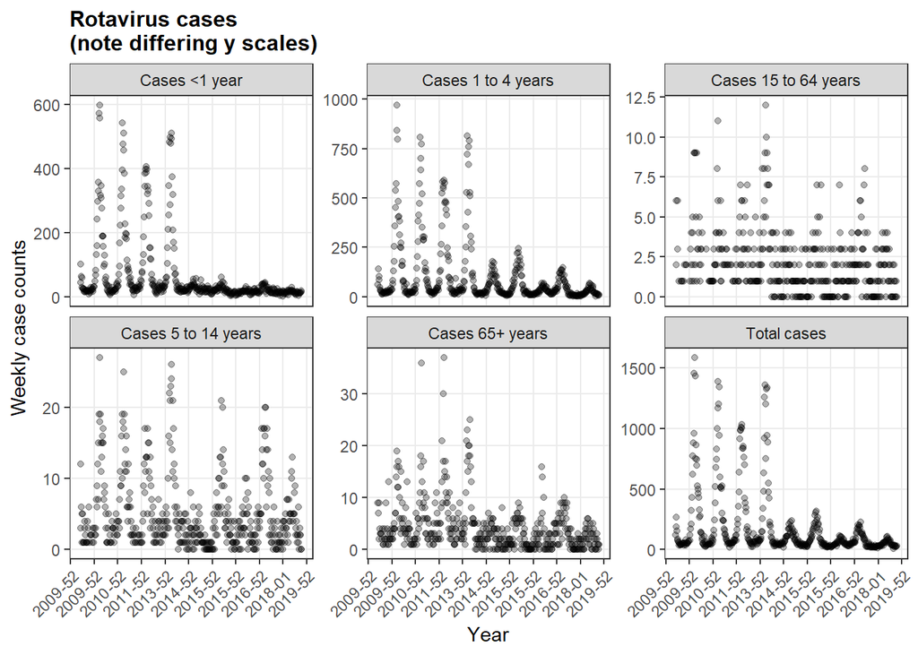

```r
ggplot(data = rota_lg) +
    geom_point(mapping = aes(x = date_index, y = n), alpha = 0.3) +
    facet_wrap(facets = vars(cases_cat), scales = "free_y") +
    scale_y_continuous(limits = c(0, NA)) +
    scale_x_yearweek(date_labels = "%Y-%W", date_breaks = "1 year") +
    labs(
        x = "Year", y = "Weekly case counts",
        title = "Rotavirus cases\n(note differing y scales)"
    ) +
      tsa_theme
```

Note that you can get line breaks in labels using `\n`. You can also make all y-axes the same by using `scales = "fixed_y"`

Now we need to state in the dataset when the vaccine was available. ##Comment from SC: Wondering if the creation of a new Date below won’t be confusing??##

For this we are adding some variables to the `rotaz` time series.

`rotaz$vaccine` will be 0 for weeks before week 27 2013, and 1 thereafter.

`rotaz$Date` will be the number of weeks since week 23 2009.

We have also created sine and cosine variables so that we can model annual seasonality as before.

```r
rotaz <-
    rota_lg %>%
    mutate(
        vaccine = case_when(
            year >= 2014 ~ 1,
            year <= 2012 ~ 0,
            year == 2013 & week >= 27 ~ 1,
            year == 2013 & week < 27 ~ 0,
            TRUE ~ NA_real_
        ),
        Date = rep(
            x = seq.int(from = 1, to = length(unique(.data$date_index)), by = 1),
            times = length(unique(.data$cases_cat))
        ),
        sin52 = sin(2 * pi * Date / 52),
        cos52 = cos(2 * pi * Date / 52)
    )

## subset to total cases
rotaz <-
    rotaz %>%
    filter(cases_cat == "Total cases")
```

Now we want to see if there was a change before and after the introduction of the vaccine.

Run first a separate model for the time before and after the introduction of the vaccine in England and Wales for all population. Can you detect any change in trend?

```r
rotamodel1 <- glm(n ~ Date,
    data = rotaz %>% filter(vaccine == 0),
    family = "poisson"
)

#Quick check for overdispersion: if check > 1 then use negative binomial
check <- summary(rotamodel1)$deviance/summary(rotamodel1)$df.residual

#proper check for overdispersion:
library(AER)
dispersiontest(rotamodel1, trafo = NULL, alternative = c("greater"))
```

```
##
##  Overdispersion test
##
## data:  rotamodel1
## z = 7.2434, p-value = 2.188e-13
## alternative hypothesis: true dispersion is greater than 1
## sample estimates:
## dispersion
##    446.172
```

```r
#so best to use a negative binomial here
rotamodel1 <- glm.nb(n ~ Date,
    data = rotaz %>% filter(vaccine == 0)
)

# Model results
glmtidy(rotamodel1, "Rotavirus model 1")
```

Rotavirus model 1

| term | estimate | std.error | statistic | p.value | conf.low | conf.high |
| --- | --- | --- | --- | --- | --- | --- |
| (Intercept) | 223.6 | 0.1485 | 36.42 | 2.052e-290 | 167.2 | 303.6 |
| Date | 1.003 | 0.001209 | 2.425 | 0.01532 | 1 | 1.005 |

```r
# Check the goodness of fit statistics.
glmstats(rotamodel1)
```

| null.deviance | df.null | logLik | AIC | BIC | deviance | df.residual | nobs |
| --- | --- | --- | --- | --- | --- | --- | --- |
| 253.9 | 211 | -1424 | 2854 | 2864 | 248.4 | 210 | 212 |

If the `summary` command is used for a `glm` Poisson model, the log rate ratios are reported by default. The `glmtidy` function converts these to rate ratios.

```r
rotamodel2 <- glm.nb(n ~ Date,
    data = rotaz %>% filter(vaccine == 1)
)

# Model results
glmtidy(rotamodel2, "Rotavirus model 2")
```

Rotavirus model 2

| term | estimate | std.error | statistic | p.value | conf.low | conf.high |
| --- | --- | --- | --- | --- | --- | --- |
| (Intercept) | 157.3 | 0.1801 | 28.08 | 1.74e-173 | 108.5 | 229.4 |
| Date | 0.9977 | 0.0005018 | -4.498 | 6.868e-06 | 0.9967 | 0.9988 |

```r
# Check the goodness of fit statistics.
glmstats(rotamodel2)
```

| null.deviance | df.null | logLik | AIC | BIC | deviance | df.residual | nobs |
| --- | --- | --- | --- | --- | --- | --- | --- |
| 310.4 | 275 | -1412 | 2830 | 2841 | 292.6 | 274 | 276 |

We show the models together for comparison below.

```r
memisc::mtable(
    "Rotavirus model 1" = rotamodel1,
    "Rotavirus model 2" = rotamodel2,
    getSummary = getSummary_expcoef,
    summary.stats = c("AIC", "BIC", "N")
)
```

[output not shown]

Run one single model for both periods (before/after the introduction of the vaccine), this time including seasonality. ##Comment SC: Why don’t we have first Date + vaccine only?

```r
rotamodel3 <- glm.nb(n ~ Date + sin52 + cos52 + vaccine,
    data = rotaz
)

# Model results
glmtidy(rotamodel3, "Rotavirus model 3")
```

Rotavirus model 3

| term | estimate | std.error | statistic | p.value | conf.low | conf.high |
| --- | --- | --- | --- | --- | --- | --- |
| (Intercept) | 203.9 | 0.05269 | 100.9 | 0 | 182.8 | 227.7 |
| Date | 0.9989 | 0.0003487 | -3.176 | 0.001493 | 0.9982 | 0.9996 |
| sin52 | 0.4245 | 0.03527 | -24.29 | 2.316e-130 | 0.3951 | 0.456 |
| cos52 | 2.053 | 0.03553 | 20.24 | 4.199e-91 | 1.909 | 2.207 |
| vaccine | 0.4885 | 0.09875 | -7.254 | 4.039e-13 | 0.4034 | 0.5919 |

```r
# Check the goodness of fit statistics.
glmstats(rotamodel3)
```

| null.deviance | df.null | logLik | AIC | BIC | deviance | df.residual | nobs |
| --- | --- | --- | --- | --- | --- | --- | --- |
| 2288 | 487 | -2607 | 5225 | 5250 | 506.4 | 483 | 488 |

We can plot the model against the raw data.

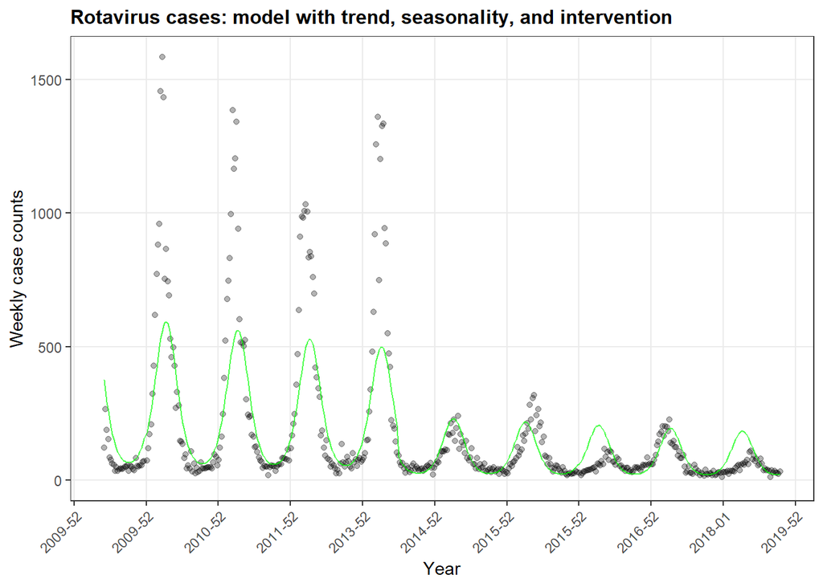

```r
rotaz <-
    bind_cols(rotaz, fitted_m3 = fitted(rotamodel3))

ggplot(data = rotaz) +
    geom_point(mapping = aes(x = date_index, y = n), alpha = 0.3) +
    geom_line(mapping = aes(x = date_index, y = fitted_m3), alpha = 0.7, colour = "green") +
    scale_y_continuous(limits = c(0, NA)) +
    scale_x_yearweek(date_labels = "%Y-%W", date_breaks = "1 year") +
    labs(
        x = "Year", y = "Weekly case counts",
        title = "Rotavirus cases: model with trend, seasonality, and intervention"
    ) +
    tsa_theme
```

To be able to comment on any change in trend after the introduction of the vaccine, we need to either include an interaction term in the model or include a time variable that starts at the introduction of the vaccine. Let’s here use an interaction term.

```r
rotamodel4 <- glm.nb(n ~ Date * vaccine + sin52 + cos52,
    data = rotaz
)

# Model results
glmtidy(rotamodel4, "Rotavirus model 4")
```

Rotavirus model 4

| term | estimate | std.error | statistic | p.value | conf.low | conf.high |
| --- | --- | --- | --- | --- | --- | --- |
| (Intercept) | 153.8 | 0.07382 | 68.21 | 0 | 133.1 | 178.4 |
| Date | 1.001 | 0.0006011 | 2.434 | 0.01494 | 1 | 1.003 |
| vaccine | 0.9833 | 0.1651 | -0.1018 | 0.9189 | 0.7076 | 1.369 |
| sin52 | 0.429 | 0.0346 | -24.46 | 4.146e-132 | 0.4001 | 0.46 |
| cos52 | 2.043 | 0.0347 | 20.6 | 3.03e-94 | 1.904 | 2.193 |
| Date:vaccine | 0.9962 | 0.0007279 | -5.2 | 1.991e-07 | 0.9948 | 0.9977 |

```r
# Check the goodness of fit statistics.
glmstats(rotamodel4)
```

| null.deviance | df.null | logLik | AIC | BIC | deviance | df.residual | nobs |
| --- | --- | --- | --- | --- | --- | --- | --- |
| 2403 | 487 | -2594 | 5202 | 5231 | 505.3 | 482 | 488 |

Have there been any changes in seasonality, too?

Note how we can use brackets to introduce interaction terms for several variables.

```r
rotamodel5 <- glm.nb(n ~ vaccine * (sin52 + cos52 + Date),
    data = rotaz
)

# Model results
glmtidy(rotamodel5, "Rotavirus model 5")
```

Rotavirus model 5 (continued below)

| term | estimate | std.error | statistic | p.value | conf.low |
| --- | --- | --- | --- | --- | --- |
| (Intercept) | 155.3 | 0.05776 | 87.35 | 0 | 138.7 |
| vaccine | 0.9175 | 0.1288 | -0.668 | 0.5041 | 0.7086 |
| sin52 | 0.2551 | 0.04127 | -33.1 | 3.035e-240 | 0.2361 |
| cos52 | 2.171 | 0.03987 | 19.45 | 2.873e-84 | 1.998 |
| Date | 1.001 | 0.0004716 | 1.325 | 0.1851 | 0.9997 |
| vaccine:sin52 | 2.631 | 0.05449 | 17.76 | 1.56e-70 | 2.37 |
| vaccine:cos52 | 0.8702 | 0.05421 | -2.564 | 0.01035 | 0.78 |
| vaccine:Date | 0.9971 | 0.0005709 | -5.167 | 2.377e-07 | 0.9959 |

| conf.high |
| --- |
| 174.3 |
| 1.19 |
| 0.2756 |
| 2.36 |
| 1.002 |
| 2.922 |
| 0.9709 |
| 0.9982 |

```r
# Check the goodness of fit statistics.
glmstats(rotamodel5)
```

| null.deviance | df.null | logLik | AIC | BIC | deviance | df.residual | nobs |
| --- | --- | --- | --- | --- | --- | --- | --- |
| 4027 | 487 | -2464 | 4945 | 4983 | 496.4 | 480 | 488 |

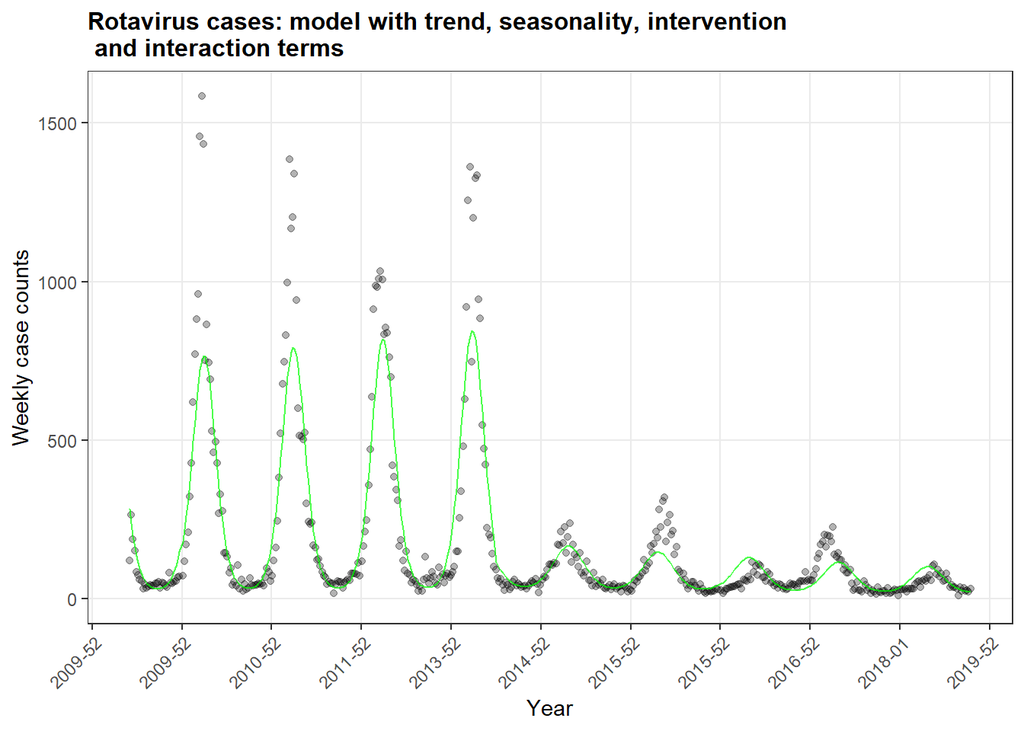

```r
rotaz <-
    bind_cols(rotaz, fitted_m5 = fitted(rotamodel5))

ggplot(data = rotaz) +
    geom_point(mapping = aes(x = date_index, y = n), alpha = 0.3) +
    geom_line(mapping = aes(x = date_index, y = fitted_m5), alpha = 0.7, colour = "green") +
    scale_y_continuous(limits = c(0, NA)) +
    scale_x_yearweek(date_labels = "%Y-%W", date_breaks = "1 year") +
    labs(
        x = "Year", y = "Weekly case counts",
        title = "Rotavirus cases: model with trend, seasonality, intervention \n and interaction terms"
    ) +
    tsa_theme
```

## SC: I would remove the code below and instead do AIC comparisons + put some hints for the second question

```r
car::linearHypothesis(
    rotamodel5,
    c("vaccine:sin52", "vaccine:cos52")
)
```

```
##
## Linear hypothesis test:
## vaccine:sin52 = 0
## vaccine:cos52 = 0
##
## Model 1: restricted model
## Model 2: n ~ vaccine * (sin52 + cos52 + Date)
##
##   Res.Df Df Chisq Pr(>Chisq)
## 1    482
## 2    480  2   320  < 2.2e-16 ***
## ---
## Signif. codes:  0 '***' 0.001 '**' 0.01 '*' 0.05 '.' 0.1 ' ' 1
```

We use the `linearHypothesis` command from the `car` package to test the hypothesis that the estimates for two of the interaction terms are both zero.

[^1]: Rotavirus infant immunisation programme 2014/15: Vaccine uptake report for England (Published: June 2015; PHE publications gateway number: 2015141)